# ex9: PPR and MARS on ozone data

PPR: projection pursuit regression MARS: multivariate adaptive regression splines

```r
set.seed(123)
data(ozone, package="gss")
```

## a) preprocessing

Take log of upo3, remove outliers, standardize predictors.

```r
chgNames <- function(dfr, oldNms, newNms) {
  colnames(dfr)[colnames(dfr) %in% oldNms] <- newNms
  dfr
}
d.ozone <- chgNames(ozone,
                    oldNms = c("upo3", "wdsp", "hmdt", "sbtp"),
                    newNms = c("O3","wind", "humidity", "temp"))
d.ozone <- subset(transform(d.ozone, "logO3" = log(O3)), select = -O3)
d.ozone.e <- d.ozone[-which.max(d.ozone[,"wind"]),] # remove outlier
d.ozone.es <- d.ozone.e
d.ozone.es[,-10] <- scale(d.ozone.e[,-10]) # standardize data
```

## b) fit with MARS

Fit with MARS:

```r
# install.packages("earth")
library(earth)
fit.MARS <- earth(logO3~., data=d.ozone.es, degree=2)
summary(fit.MARS)
```

```
## Call: earth(formula=logO3~., data=d.ozone.es, degree=2)
##
##                                           coefficients
## (Intercept)                                  2.7892202
## h(-0.558752-humidity)                       -0.2625085
## h(-0.680117-temp)                           -0.2569552
## h(temp- -0.680117)                           0.3327532
## h(-0.830631-ibht)                           -0.5855155
## h(-0.119086-dgpg)                           -0.1879522
## h(dgpg- -0.119086)                          -0.2802249
## h(0.424312-ibtp)                            -0.3530348
## h(0.95792-vsty)                              0.1556507
## h(-1.09286-day)                             -1.3994423
## h(day- -1.09286)                            -0.2880581
## h(wind-1.01947) * h(0.95792-vsty)           -0.2567170
## h(-0.709556-humidity) * h(-0.680117-temp)    0.5171961
## h(humidity-0.446605) * h(ibht- -0.830631)   -0.3217144
##
## Selected 14 of 21 terms, and 8 of 9 predictors
## Termination condition: Reached nk 21
## Importance: temp, ibtp, day, humidity, ibht, dgpg, vsty, wind, ...
## Number of terms at each degree of interaction: 1 10 3
## GCV 0.1062103    RSS 28.18939    GRSq 0.8111275    RSq 0.8467021
```

plot the main effects and then the interactions using `plotmo`

```
##  grid:    vdht       wind humidity       temp       ibht      dgpg
##     0.08458558 0.07466517 0.295801 0.01263375 -0.2533793 0.1889708
##        ibtp        vsty         day
##  0.08421041 -0.05243726 -0.03749141
```

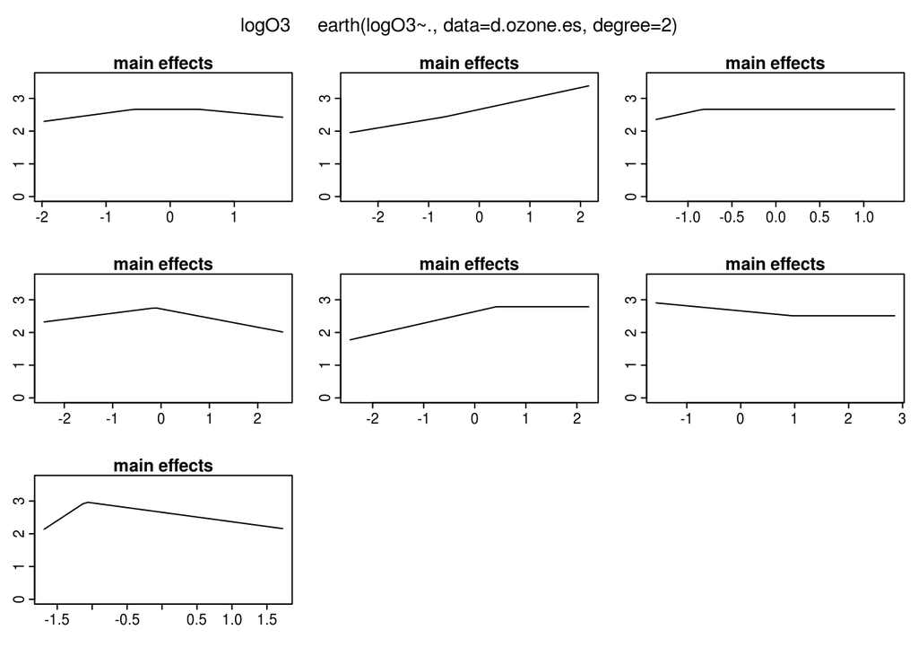

```r
plotmo(fit.MARS, degree2=F, main="main effects")
```

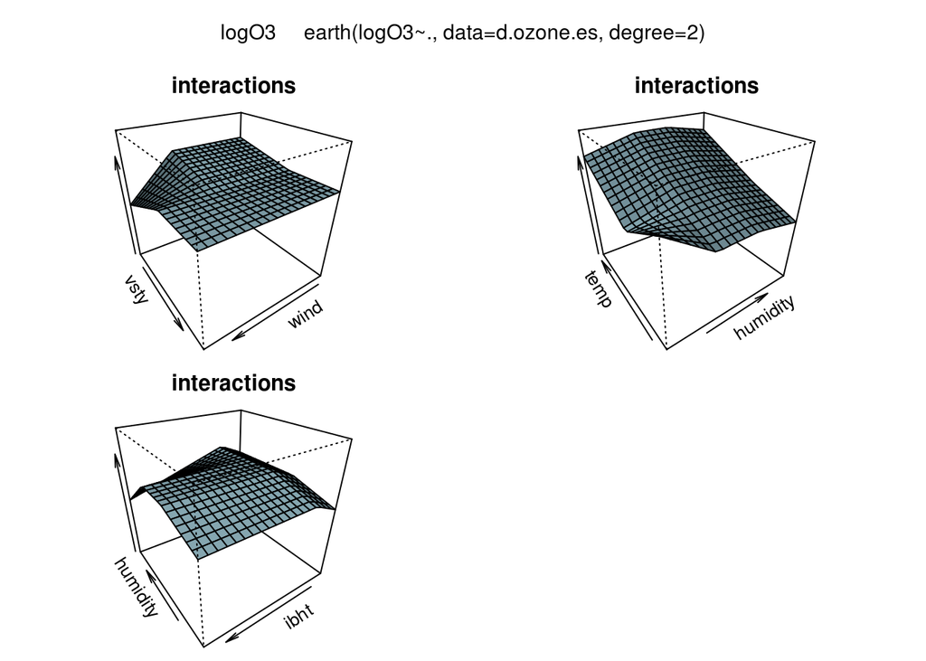

```r
plotmo(fit.MARS, degree1=F, main="interactions")
```

## c) fit with PPR

To plot the fit (4 terms, 4 ridge functions to plot), use `sfsmisc::mult.fig` to setup plot par.

```r
fit.PPR <- ppr(logO3~., data=d.ozone.es, nterms=4)
summary(fit.PPR)
```

```
## Call:
## ppr(formula = logO3 ~ ., data = d.ozone.es, nterms = 4)
##
## Goodness of fit:
##  4 terms
## 30.60059
##
## Projection direction vectors:
##          term 1       term 2       term 3       term 4
## vdht      0.002466343 -0.110279366  0.335579691  0.063058720
## wind     -0.025314264  0.047798465 -0.107956109 -0.321585600
## humidity  0.213107648  0.053307310  0.115710178 -0.117217469
## temp      0.876575427  0.249824985 -0.145537257  0.023761677
## ibht     -0.369038142 -0.036228573  0.441738014 -0.385181776
## dgpg     -0.015825765 -0.243279739 -0.752690565  0.411360829
## ibtp      0.024923696 -0.133404863  0.053941938 -0.726312965
## vsty     -0.181763389 -0.075948875 -0.158041049  0.122534650
## day      -0.124318268 -0.914459920 -0.227155334  0.134810056
##
## Coefficients of ridge terms:
##     term 1     term 2     term 3     term 4
## 0.63456590 0.25644807 0.19492231 0.09808657
```

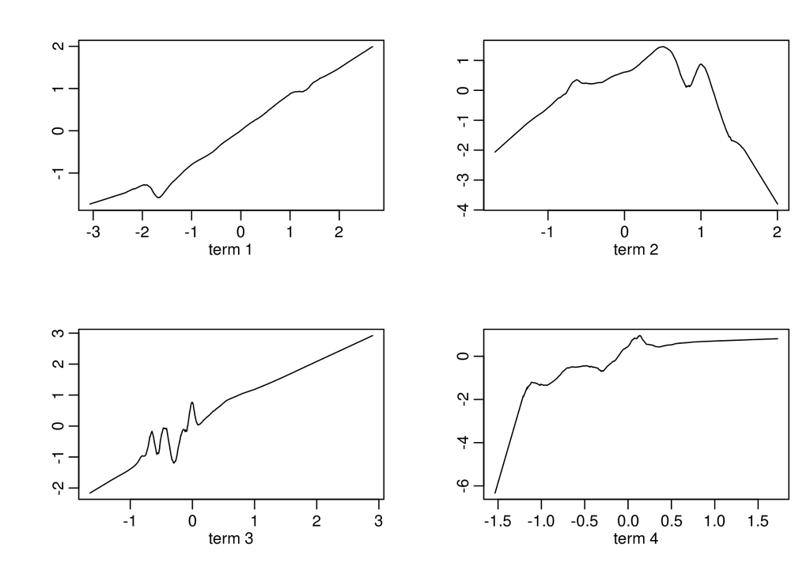

```r
library(sfsmisc)
mult.fig(4)
plot(fit.PPR, type="l")
```

Remark: >Fitted lines of ridge funcitons are too wiggly, therefore model is not optimal. A better model could have smoother fitted ridge lines.

## d) find best PPR param using CV

The given cv function:

```r
cv <- function(fitfn, formula = logO3 ~ . , data = d.ozone.es, ..., trace = TRUE){
  modFrame <- model.frame(formula, data = data)
  nc <- nrow(data)
  ssr <- 0
  if(trace) cat(" j = ")
  for(j in 1:nc) {
  if(trace) cat(if(j %% (nc %/% 10) == 1) paste(j, "") else ".")
  ## Fit without 'j' :
  fit <- fitfn(formula=formula, data = data[-j ,], ...)
  ## Evaluate at 'j' :
  ssr <- ssr + (model.response(modFrame)[j] - predict(fit, modFrame[j,]))^2
  }
  if(trace) cat("\n")
  ssr
}
```

Search for best param, the grid is: nterms=3:5, sm.method=c(“supsmu”, “spline”, “gcvspline”), df=5:7(only for spline), max.terms = nterms+3:

We use a list of vectors/matrix to store the cv results, and for better printing, we use `names` and `dimnames` to specify a name for each cv score. To concat a prefix to a vector, use `paste`.

```r
nterms.grid <- 3:5
df.grid <- 5:7
# store cv scores for the 3 sm.method into a list
cv.scores <- list( supsmu=numeric(3), gcvspline=numeric(3),
               spline=matrix(0, nrow=3, ncol=3) ) # for splines there are 2 params, so use a matrix

# add names to the vectors/matrix
names(cv.scores$gcvspline) <- names(cv.scores$supsmu) <- paste("nterms=", nterms.grid, sep="")
dimnames(cv.scores$spline) <- list(paste('nterms=', nterms.grid, sep=""), paste("df=", df.grid, sep=""))

for(i in seq_along(nterms.grid)){ # very slow...
  cat("i=", i, "...")
  nt <- nterms.grid[i]
  cv.scores$supsmu[i] <- cv(ppr, sm.method="supsmu",nterms=nt, max.terms=nt+3, trace=F)
  cv.scores$gcvspline[i] <- cv(ppr, sm.method="gcvspline", nterms=nt, max.terms=nt+3, trace=F)
  for(j in seq_along(df.grid))
    cv.scores$spline[i,j] <- cv(ppr, sm.method="spline", nterms=nt, max.terms=nt+3, df=df.grid[j], trace=F)
  cat("...done. \n")
}
```

```
## i= 1 ......done.
## i= 2 ......done.
## i= 3 ......done.
```

## e) fit MARS seraching for best degree of interaction

```r
deg.grid=1:3
cv.scores <- c(cv.scores, mars=list(numeric(3))) # append another vector
names(cv.scores$mars) <- paste("degree=", deg.grid, sep="")
for(i in seq_along(deg.grid))
  cv.scores$mars[i] <- cv(earth, degree=deg.grid[i], trace=F)
```

add the gam model:

```r
library(mgcv)
wrapGam <- function(formula, data,...){
  gamForm <- wrapFormula(formula, data = data)
  gam(gamForm, data=data, ...)
}
gam.cv <- cv(wrapGam, formula=logO3~., trace=T)
```

```
##  j = 1 ...............................33 ...............................65 ...............................97 ...............................129 ...............................161 ...............................193 ...............................225 ...............................257 .............…
```

```r
cv.scores <- c(cv.scores, gam=gam.cv) # append a number
```

compare the models:

```r
print(cv.scores)
```

```
## $supsmu
## nterms=3 nterms=4 nterms=5
## 53.05948 54.07697 53.92102
##
## $gcvspline
## nterms=3 nterms=4 nterms=5
## 53.17953 54.75474 58.35856
##
## $spline
##              df=5     df=6     df=7
## nterms=3 40.23206 38.70816 43.42077
## nterms=4 38.76893 35.00961 43.22224
## nterms=5 38.38503 36.25633 44.19653
##
## $mars
## degree=1 degree=2 degree=3
## 40.93322 38.34400 40.08850
##
## $gam.1
## [1] 37.97607
```

Remarks: >The PPR with spline(df=6 nterms=4) performs best. The gam model performs also quite good.

## f) plot best PPR model

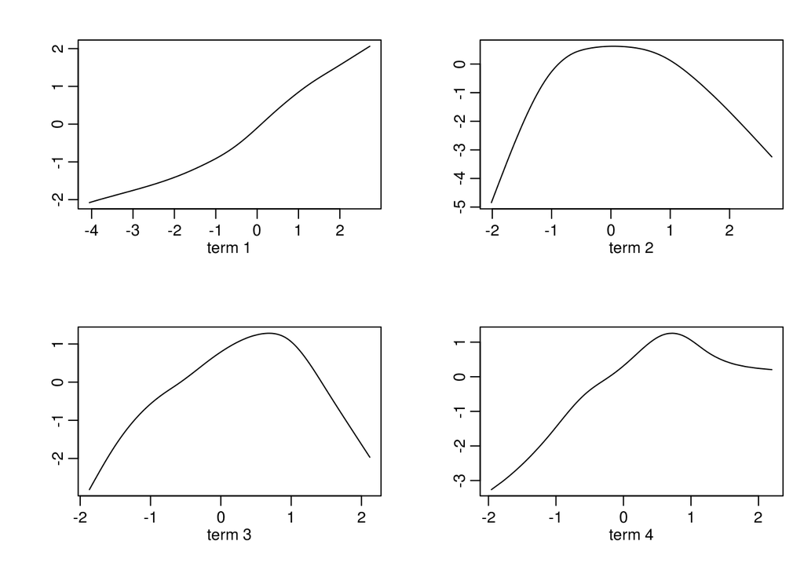

```r
fit.PPRbest <- ppr(logO3~., data=d.ozone.es,
                   sm.method="spline", nterms=4, max.terms=7, df=6)
mult.fig(4)
plot(fit.PPRbest, type="l")
```

==> the best cv-selected model looks smoother.

## g) interpret the alpha matrix

The PPR model (P70 in notes) is:

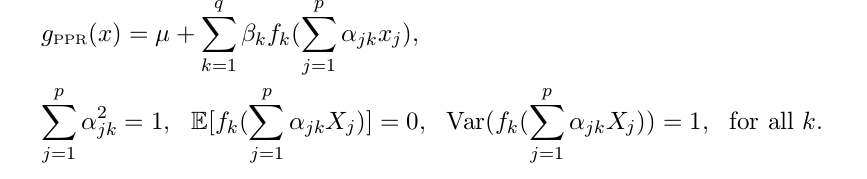

```r
round( fit.PPRbest$beta, digits = 3)
```

```
## term 1 term 2 term 3 term 4
##  0.534  0.263  0.312  0.305
```

```r
round( fit.PPRbest$alpha, digits = 3)
```

```
##          term 1 term 2 term 3 term 4
## vdht      0.483 -0.086 -0.056 -0.016
## wind     -0.254 -0.110  0.091  0.117
## humidity -0.029 -0.544  0.156  0.224
## temp      0.480  0.429 -0.037 -0.370
## ibht     -0.057 -0.174 -0.048  0.008
## dgpg      0.467 -0.455 -0.114 -0.659
## ibtp      0.075 -0.103 -0.104  0.322
## vsty     -0.436 -0.104  0.052  0.256
## day      -0.232 -0.492 -0.966  0.442
```

> The coefficient of the variable `ibht` has relatively small absolute values in all of the terms => it seems to be not so important. `term 3` is dominated mainly by the value of `day`, whereas the other three terms each involve at least 4 variables and are less interpretable…